# MAC0460 - Intruduction to machine learning

## EP5: Neural networks and scikit-learn

Felipe Castro de Noronha @ IME-USP 2020

In this project we are going to explore out knowledge in **neural networks** modeling using the [scikit learn](https://scikit-learn.org/stable/) framework. The previews tasks of this discipline provided application of fundamental topics in machine learning, such as the **perceptron** and **linear regression**.

This time we are going to build a **multi-layer perceptron classifier** (MLP) for the [MNIST dataset](http://yann.lecun.com/exdb/mnist/), hence we are going to predict labels for handwritten digits. We are going to develop this project in 3 parts:

- **Data preparation**: the first part is to extract the data from the dateset and build a **reduced** (used in cross validation) and a **complete** (used in the training) set, both being reshaped and normalized to fit in the models correctly.
- **Model selection**: we are going to use the **5-fold stratified cross-validation** method to evaluete the best model/architeture for our network, looking for the accuracy to make our decision toward the best fitting model.
- **Selected model evaluation**: Finally we are going to train the choosen model using the complete sets. During this process we will be able to take some metrics such as **loss error** during the training and the **confusion matrix** after the training.

### 1 Data preparation

The next code cells deal with the preparation of the dataset used. This part is essencial to the correct training of the network since the MLP is vary sensible to the input. All the preparation is done in this cells and nothing is left to be made later in the code.

#### 1.1 MNIST dataset

This is a well known dataset, commonly used as a first example of image classification tasks. It consists of handwritten digits, divided into $60000$ training images and $10000$ test images. All images are gray-scale (one channel with pixel intensities varying from 0 to 255) and have size $784$ (the image from sklearn is already flatterned). There are 10 classes, corresponding to digits 0 to 9.

```python
from sklearn.datasets import fetch_openml

mnist = fetch_openml('mnist_784', version=1)
# extracting training and test parts of the dataset
x_train_all, y_train_all = mnist.data[:60000].astype('float32'), mnist.target[:60000].astype('float32')
x_test_all, y_test_all = mnist.data[60000:].astype('float32'), mnist.target[60000:].astype('float32')

print("x_train_all shape: {0} --- y_train_all shape: {1}".format(x_train_all.shape, y_train_all.shape))
print("x_test_all shape: {0} --- y_test_all shape: {1}".format(x_test_all.shape, y_test_all.shape))
```

```
x_train_all shape: (60000, 784) --- y_train_all shape: (60000,)
x_test_all shape: (10000, 784) --- y_test_all shape: (10000,)
```

#### 1.2 Extracting features

In our Neural network we are going to use the intersity of the pixels of the image. This value is going to be normalized to fit the $[0,1]$ interval and by doing this we garantee a better performance/estability of our MLP.

```python
from sklearn.preprocessing import minmax_scale
import matplotlib.pyplot as plt

# image features with normalization in [0,1]
x_train_features = x_train_all/255
x_test_features = x_test_all/255
```

#### 1.3 Separating reduced training set

Here we are going to create a reduced traning set, consisting of $n\_samples = 2000$ examples of each class. The focus of the reduced set is to decrease the amount of time and processing needed in order to make the cross validation. After this we will have:

- `x_train` and `y_train` as the reduced sets for cross validation
- `x_test` and `y_test` as the original test sets from the dataset
- `x_train_complete` and `y_train_complete` as the complete sets to be used in the final training

```python
from sklearn.utils import shuffle
import numpy as np

# number of samples from each class to be inserted in the reduced set
n_sample = 2000

# getting reduced test set with same amount of samples from each class
x_train_reduced = y_train_reduced = None
for c in range(10):
    itens = [i for i in range(len(x_train_features)) if int(y_train_all[i]) == c]
    x_tmp, y_tmp = shuffle(x_train_features[itens], y_train_all[itens])

    if x_train_reduced is None:
        x_train_reduced, y_train_reduced = x_tmp[:n_sample], y_tmp[:n_sample]
        continue

    x_train_reduced = np.concatenate([x_train_reduced, x_tmp[:n_sample]])
    y_train_reduced = np.concatenate([y_train_reduced, y_tmp[:n_sample]])

print("x_train_reduced shape: {0} --- y_train_reduced shape: {1}".format(x_train_reduced.shape, y_train_reduced.shape))

# getting final sets
x_train, y_train = shuffle(x_train_reduced, y_train_reduced)
x_test, y_test = x_test_features, y_test_all
x_train_complete, y_train_complete = shuffle(x_train_features, y_train_all)
```

```
x_train_reduced shape: (20000, 784) --- y_train_reduced shape: (20000,)
```

#### 1.4 Sets information

Here we get some information about each one of the sets and plot $6$ from the reduced training set.

```
x_train -- dtype: float32 | shape: (20000, 784) | min value: 0.0 | max value: 1.0
y_train -- dtype: float32 | shape: (20000,) | min value: 0.0 | max value: 9.0

x_test -- dtype: float32 | shape: (10000, 784) | min value: 0.0 | max value: 1.0
y_test -- dtype: float32 | shape: (10000,) | min value: 0.0 | max value: 9.0

x_train_complete -- dtype: float32 | shape: (60000, 784) | min value: 0.0 | max value: 1.0
y_train_complete -- dtype: float32 | shape: (60000,) | min value: 0.0 | max value: 9.0
```

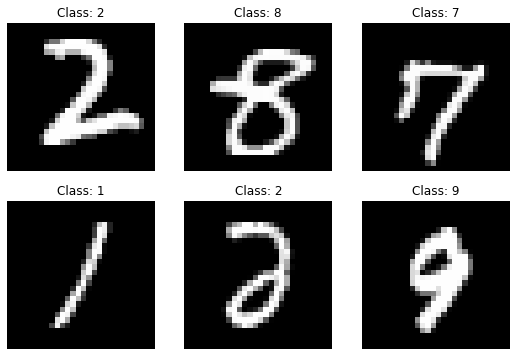

```python
def print_info(label, x):
    print("{0} -- dtype: {1} | shape: {2} | min value: {3} | max value: {4}".format(\
        label, x.dtype, x.shape, np.amin(x), np.amax(x)))

print_info("x_train", x_train)
print_info("y_train", y_train)
print("")
print_info("x_test", x_test)
print_info("y_test", y_test)
print("")
print_info("x_train_complete", x_train_complete)
print_info("y_train_complete", y_train_complete)
print("")

# printing 6 images of the training set
fig, ax = plt.subplots(2, 3, figsize = (9, 6))
rl = np.random.choice(len(x_train), 6)
for i, j in zip(range(6), rl):
    ax[i//3, i%3].imshow(x_train[j].reshape((28,28))*255, cmap='gray')
    ax[i//3, i%3].axis('off')
    ax[i//3, i%3].set_title("Class: %d"%y_train[j])
plt.show()
```

#### 1.5 Intensity distribution

Finally we can show the mean intensity distribution of each class of the dataset using a violing plot.

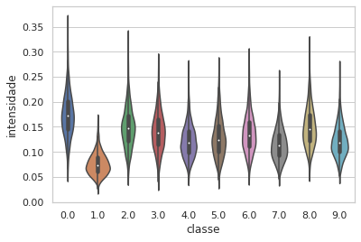

```python
import seaborn as sns
import pandas as pd
sns.set(style="whitegrid")

mean_intensity = [np.mean(image) for image in x_train]
# intensity distribution in each class using violin plot
df = pd.DataFrame({'intensidade':mean_intensity, 'classe':y_train})
ax = sns.violinplot(x='classe', y='intensidade', data=df)
```

### 2 Model selection

This is the most important part in our project. To chose a good model (in order words, a model/architeture/network that has a high probability of giving us the rigth label for an image) we must have a good and reliable way to mesure the accuracy of that model.

To do this we are going to use the [model selection API providade by sklearn](https://scikit-learn.org/stable/modules/cross_validation.html), this API enable us to make a **5-fold** (divide the reduced train set into 5 groups/folds) **stratified** (each class will have the same number of representants in each fold) **cross-validation** (process made for each folder, taking the corresponding one to evaluete the error in the model trained by the others) in each one of the presented models.

To create the models itself we are going to use the [MLPClassifier](https://scikit-learn.org/stable/modules/generated/sklearn.neural_network.MLPClassifier.html), a multi-layer perceptron classifier provided in sklearn that enable us to specify a big variety of **hyperparameters** such as the hidden layers layout, activation function, solver, number of iterations and much more.

```python
from sklearn.model_selection import StratifiedKFold
from sklearn.neural_network import MLPClassifier
```

#### 2.1 Models

Here we are going to create our prediction models. Our models are going to be specified as lines in the list `model_param`, this way the process of creating new instances of a `MLPClassifier` will be very easy.

The sklearn easily deal with classification problems, hence in all our models the 10-sized output layer is as softmax output funtion. Also, at the current moment, it is only able to minimize the cross-entropy loss function to fit the data, in other words, to learn.

The model 0 (first in the list) is Based on [François Chollet model presented here](https://github.com/fchollet/deep-learning-with-python-notebooks/blob/master/2.1-a-first-look-at-a-neural-network.ipynb). The network has 512 nodes in the first layer and 10 in the second one, the batch size is of 128 samples.

Each one of the following models vary only in the number of layers, the number of nodes in each layer and the activation function.

Also, for all the models we:

- Used the $adam$ (stochastic gradient-based optimizer) as solver, because all the other solvers perfomed badly in *off-screen* tests
- Used $batch\_size=128$
- Fixed $max\_iter=10$ for a consistent analisys of each one

```python
# parameters for each one of the models we are going to test
model_param = [[(512, 10), 'relu'], \
              [(784, 10), 'relu'], \
              [(784, 784, 10), 'relu'], \
              [(784, 784, 10), 'tanh'], \
              [(784, 784, 10), 'identity'], \
              [(784, 784, 784, 10), 'relu'], \
              [(1024, 10), 'relu'], \
              [(1024, 1024, 10), 'relu'], #optimal
              [(1024, 1024, 1024, 10), 'relu'], \
              [(1024, 1024, 1024, 1024, 10), 'relu'], \
              [(1024, 1024, 1024, 1024, 1024, 10), 'relu'], \
              [(1024, 1024, 1024, 1024, 512, 256, 10), 'relu'], \
              [(256, 10), 'relu'], \
              [(512, 512, 10), 'relu'], \
              [(512, 512, 512, 10), 'relu'], \
              [(512, 1024, 10), 'relu'], \
              [(1024, 512, 256, 10), 'relu'], \
              [(1024, 512, 256, 10), 'tanh'], \
              [(1024, 512, 256, 10), 'identity'], \
              [(256, 512, 1024, 10), 'relu']]

number_models = len(model_param)
```

#### 2.2 5-fold cross validation

Now we finally are going to train some neural networks. Using the [StratifiedKFold method from sklearn](https://scikit-learn.org/stable/modules/generated/sklearn.model_selection.StratifiedKFold.html) we divided the reduced training ser into 5 **folds** and though a loop each fold was used as test set while the rest were used to train the model.

That train of a model is made by the mothod `fit()` and after that we can measure the error between the prediction and the actual labels.

In the output console is possible to check the **accuracy** of each model in each fold iteration for both training and testing sets. The final accuracy is a result of the mean of the 5 observed accuracies and we are looking toward this final result to make our decision of the best architeture.

```python
from collections import Counter

# to remove annoying warnings
from warnings import simplefilter
from sklearn.exceptions import ConvergenceWarning
simplefilter("ignore", category=ConvergenceWarning)

# stratified 5-fold used for cross validation
skf = StratifiedKFold(n_splits=5)
folder_number = 1
accuracy_history = [[] for m in range(number_models)]

# train and test are lists of indexes
for train, test in skf.split(x_train, y_train):
    # train and test sets for this fold
    x_train_f, y_train_f = x_train[train], y_train[train]
    x_test_f, y_test_f = x_train[test], y_train[test]

    print("---------------------------------------------------------")
    print("Class distribution in folder {0}:".format(folder_number))
    amt_train = [x[1] for x in sorted(zip(list(Counter(y_train_f).keys()), Counter(y_train_f).values()))]
    amt_test = [x[1] for x in sorted(zip(list(Counter(y_test_f).keys()), Counter(y_test_f).values()))]
    print(pd.DataFrame({'train set':amt_train, 'test_set':amt_test}, range(10)).T)
    print("")

    for m in range(number_models):
        # new model to be trained
        model = MLPClassifier(hidden_layer_sizes=model_param[m][0], activation=model_param[m][1], \
                              solver='adam', batch_size=128, max_iter=10)

        model.fit(x_train_f, y_train_f)
        train_acc = model.score(x_train_f, y_train_f)
        test_acc = model.score(x_test_f, y_test_f)
        accuracy_history[m].append([train_acc, test_acc])
        print("Model {0}: {1:.2f}% accuracy on train set and {2:.2f}% accuracy on test set".format(\
            m, train_acc*100, test_acc*100))

    folder_number += 1

print("---------------------------------------------------------")
print("\nFinal accuracy of the models:")
for m in range(number_models):
    print("Model {0}: {1:.2f}% of accuracy in train sets and {2:.2f}% of accuracy in test sets".format(\
        m, np.mean(accuracy_history[m], axis=0)[0]*100, np.mean(accuracy_history[m], axis=0)[1]*100))
```

```
---------------------------------------------------------
Class distribution in folder 1:
              0     1     2     3     4     5     6     7     8     9
train set  1600  1600  1600  1600  1600  1600  1600  1600  1600  1600
test_set    400   400   400   400   400   400   400   400   400   400

Model 0: 99.83% accuracy on train set and 96.55% accuracy on test set
Model 1: 99.79% accuracy on train set and 95.95% accuracy on test set
Model 2: 99.67% accuracy on train set and 96.58% accuracy on test set
Model 3: 99.45% accuracy on train set and 96.47% accuracy on test set
Model 4: 92.64% accuracy on train set and 89.55% accuracy on test set
Model 5: 99.44% accuracy on train set and 96.35% accuracy on test set
Model 6: 99.92% accuracy on train set and 96.40% accuracy on test set
Model 7: 99.63% accuracy on train set and 96.62% accuracy on test set
Model 8: 99.38% accuracy on train set and 96.20% accuracy on test set
Model 9: 99.28% accuracy on train set and 96.53% accuracy on test set
Model 10: 99.62% accuracy on train set and 96.28% accuracy on test set
Model 11: 97.70% accuracy on train set and 94.77% accuracy on test set
Model 12: 99.54% accuracy on train set and 96.28% accuracy on test set
Model 13: 99.78% accuracy on train set and 96.67% accuracy on test set
Model 14: 99.78% accuracy on train set and 96.53% accuracy on test set
Model 15: 99.25% accuracy on train set and 95.35% accuracy on test set
Model 16: 99.77% accuracy on train set and 96.92% accuracy on test set
Model 17: 99.41% accuracy on train set and 96.28% accuracy on test set
Model 18: 93.11% accuracy on train set and 90.50% accuracy on test set
Model 19: 99.84% accuracy on train set and 96.92% accuracy on test set
---------------------------------------------------------
Class distribution in folder 2:
              0     1     2     3     4     5     6     7     8     9
train set  1600  1600  1600  1600  1600  1600  1600  1600  1600  1600
test_set    400   400   400   400   400   400   400   400   400   400

Model 0: 99.43% accuracy on train set and 95.88% accuracy on test set
Model 1: 99.85% accuracy on train set and 96.53% accuracy on test set
Model 2: 99.98% accuracy on train set and 96.88% accuracy on test set
Model 3: 98.91% accuracy on train set and 95.83% accuracy on test set
Model 4: 90.77% accuracy on train set and 89.30% accuracy on test set
Model 5: 99.16% accuracy on train set and 96.38% accuracy on test set
Model 6: 99.94% accuracy on train set and 97.08% accuracy on test set
Model 7: 99.72% accuracy on train set and 96.60% accuracy on test set
```

[output cut: 98 more lines]

```
Model 5: 99.32% of accuracy in train sets and 96.13% of accuracy in test sets
Model 6: 99.91% of accuracy in train sets and 96.48% of accuracy in test sets
Model 7: 99.74% of accuracy in train sets and 96.71% of accuracy in test sets
Model 8: 99.45% of accuracy in train sets and 96.36% of accuracy in test sets
Model 9: 99.24% of accuracy in train sets and 96.30% of accuracy in test sets
Model 10: 98.78% of accuracy in train sets and 96.01% of accuracy in test sets
Model 11: 98.94% of accuracy in train sets and 96.05% of accuracy in test sets
Model 12: 99.50% of accuracy in train sets and 96.00% of accuracy in test sets
Model 13: 99.55% of accuracy in train sets and 96.32% of accuracy in test sets
Model 14: 99.20% of accuracy in train sets and 95.97% of accuracy in test sets
Model 15: 99.72% of accuracy in train sets and 96.18% of accuracy in test sets
Model 16: 99.54% of accuracy in train sets and 96.40% of accuracy in test sets
Model 17: 99.00% of accuracy in train sets and 95.83% of accuracy in test sets
Model 18: 92.82% of accuracy in train sets and 90.17% of accuracy in test sets
Model 19: 99.49% of accuracy in train sets and 96.13% of accuracy in test sets
```

### 3 Selected model evaluation

Now we going to use the whole reduced test set to train the best model. From this *ultimate training* we are going to get some good metrics on the quality of our network, for instance, the confusion matrix over the test set.

#### 3.1 Complete training

As we saw in the above block, the model with the `(1024, 1024, 10)` layers layout using `relu` activation function had the best accuracy on the tests sets of the cross validation and is very simple, hence this will be our choosen one.

```python
# to remove annoying warnings
from warnings import simplefilter
from sklearn.exceptions import ConvergenceWarning
simplefilter("ignore", category=ConvergenceWarning)

model = MLPClassifier(hidden_layer_sizes=(1024, 1024, 10), activation='relu', solver='adam', \
                      batch_size=128, max_iter=10, verbose=True)
model.fit(x_train, y_train)
print("Model has {0:.2f}% accuracy on train set and {1:.2f}% accuracy on test set".format(\
        model.score(x_train, y_train)*100, model.score(x_test, y_test)*100))
```

```
Iteration 1, loss = 0.78711564
Iteration 2, loss = 0.18742296
Iteration 3, loss = 0.10649542
Iteration 4, loss = 0.06838588
Iteration 5, loss = 0.04878310
Iteration 6, loss = 0.02274672
Iteration 7, loss = 0.02258484
Iteration 8, loss = 0.01874597
Iteration 9, loss = 0.01444613
Iteration 10, loss = 0.02352604
Model has 99.39% accuracy on train set and 96.34% accuracy on test set
```

#### 3.2 Training curve

From the difinition in the [sklearn website](https://scikit-learn.org/stable/modules/learning_curve.html#learning-curve) we have *"A learning curve shows the validation and training score of an estimator for varying numbers of training samples. It is a tool to find out how much we benefit from adding more training data and whether the estimator suffers more from a variance error or a bias error."*.

We are going to use the [learning_curve() method](https://scikit-learn.org/stable/modules/generated/sklearn.model_selection.learning_curve.html#sklearn.model_selection.learning_curve) to help us doing this job, wich is based on 5-fold stratified cross validation of the training set. To generate the following plots I took inspiration in [this tutorial from Chris Albon](https://chrisalbon.com/machine_learning/model_evaluation/plot_the_learning_curve/).

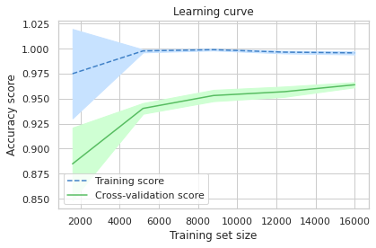

```python
from sklearn.model_selection import learning_curve

train_sizes, train_scores, test_scores = learning_curve(MLPClassifier(hidden_layer_sizes=(1024, 1024, 10),
                                                        activation='relu', solver='adam', \
                                                        batch_size=128, max_iter=10), \
                                                        x_train, y_train, scoring='accuracy', \
                                                        cv=5)
# means and standard deviations of training set scores
train_mean, train_std = np.mean(train_scores, axis=1), np.std(train_scores, axis=1)
# means and standard deviations of test set scores
test_mean, test_std = np.mean(test_scores, axis=1), np.std(test_scores, axis=1)
plt.plot(train_sizes, train_mean, '--', color="#4081c7",  label="Training score")
plt.plot(train_sizes, test_mean, color="#57bd61", label="Cross-validation score")
plt.fill_between(train_sizes, train_mean-train_std, train_mean+train_std, color="#c7e2ff")
plt.fill_between(train_sizes, test_mean-test_std, test_mean+test_std, color="#cfffd3")
plt.title("Learning curve")
plt.xlabel("Training set size"), plt.ylabel("Accuracy score")
plt.legend(loc="best")
plt.tight_layout()
plt.show()
```

#### 3.2 Confusion matrix

A confusion matrix is a very visual way for us to se the quality of our model. From the [wikipedia definition](https://en.wikipedia.org/wiki/Confusion_matrix) we have *"Each row of the matrix represents the instances in a predicted class while each column represents the instances in an actual class (or vice versa). The name stems from the fact that it makes it easy to see if the system is confusing two classes"*.

For this we are going to use the [plot confusion matrix method from sklearn](https://scikit-learn.org/stable/modules/generated/sklearn.metrics.plot_confusion_matrix.html#sklearn.metrics.plot_confusion_matrix).

```
Class distribution in the test set:
            0     1     2     3    4    5    6     7    8     9
test set  980  1135  1032  1010  982  892  958  1028  974  1009
```

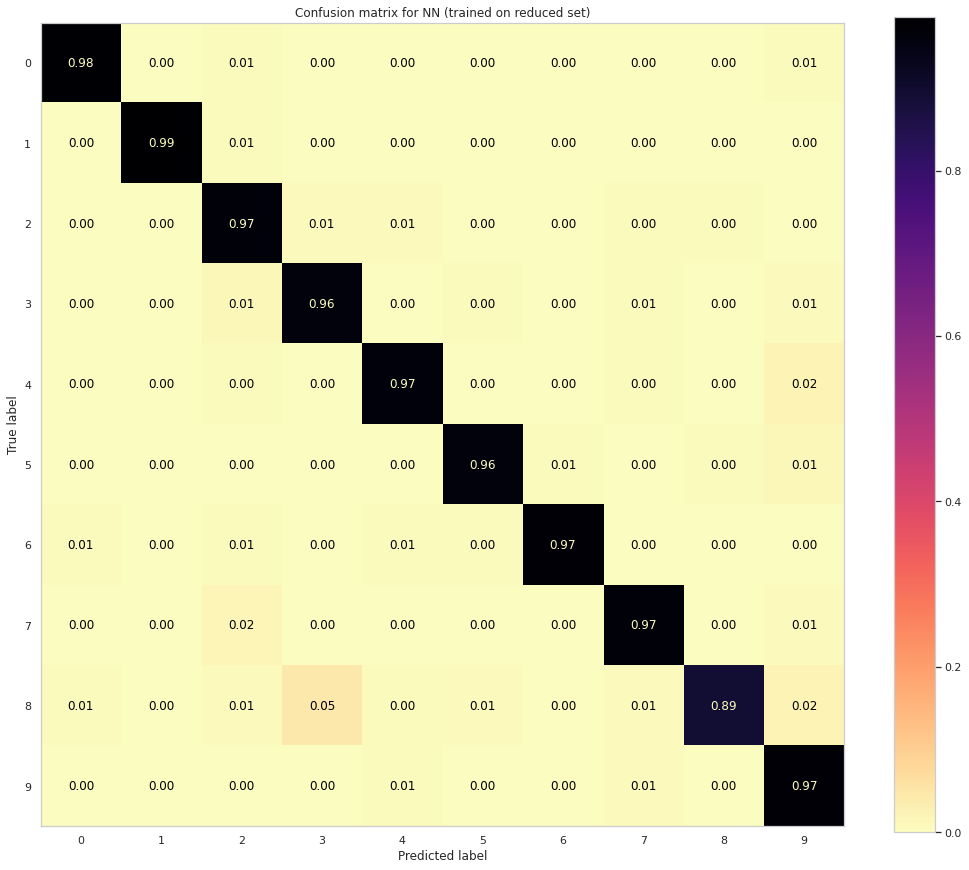

```python
from sklearn.metrics import confusion_matrix
from sklearn.metrics import plot_confusion_matrix

print("Class distribution in the test set:")
amt_test = [x[1] for x in sorted(zip(list(Counter(y_test).keys()), Counter(y_test).values()))]
print(pd.DataFrame({'test set':amt_test}, range(10)).T)

fig, ax = plt.subplots(1, 1, figsize = (18, 15))
disp = plot_confusion_matrix(model, x_test, y_test, display_labels=range(10),
                             cmap=plt.cm.magma_r, normalize='true',
                             ax=ax, values_format='.2f')
disp.ax_.set_title('Confusion matrix for NN (trained on reduced set)')
plt.grid(False)
plt.show()
```

#### 3.3 Visualization of MLP weights

Following [this tutorial from sklearn](https://scikit-learn.org/stable/auto_examples/neural_networks/plot_mnist_filters.html) we are going to visualize the weights of some nodes in our network.

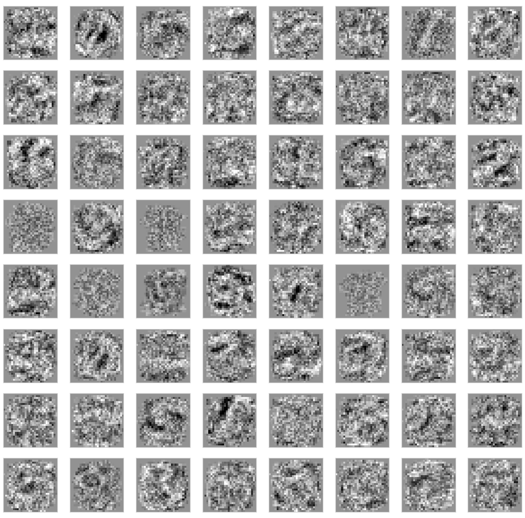

```python
fig, axes = plt.subplots(8, 8, figsize=(20, 20))
# ensure all weights are shown on the same scale
vmin, vmax = model.coefs_[0].min(), model.coefs_[0].max()
for coef, ax in zip(model.coefs_[0].T, axes.ravel()):
    ax.matshow(coef.reshape(28, 28), cmap=plt.cm.gray, vmin=.5*vmin, vmax=.5*vmax)
    ax.set_xticks(())
    ax.set_yticks(())
plt.show()
```

#### 3.4 Model evaluation with complete set

This last part is not in the script of this task. But here I want to train the model with the complete test set of 60000 samples, exploring some other parameters, as the use of a **validation** set.

```
Iteration 1, loss = 0.26716877
Validation score: 0.961167
Iteration 2, loss = 0.09275440
Validation score: 0.966333
Iteration 3, loss = 0.06111612
Validation score: 0.977000
Iteration 4, loss = 0.04854093
Validation score: 0.979333
Iteration 5, loss = 0.03901874
Validation score: 0.975167
Iteration 6, loss = 0.03306326
Validation score: 0.977500
Iteration 7, loss = 0.03204021
Validation score: 0.979167
Iteration 8, loss = 0.02456025
Validation score: 0.974500
Iteration 9, loss = 0.02622817
Validation score: 0.979333
Iteration 10, loss = 0.02348292
Validation score: 0.979667
Iteration 11, loss = 0.02194983
Validation score: 0.972500
Iteration 12, loss = 0.02376569
Validation score: 0.978000
Iteration 13, loss = 0.01781874
Validation score: 0.976333
Iteration 14, loss = 0.02187255
Validation score: 0.979833
Iteration 15, loss = 0.02089159
Validation score: 0.978167
Iteration 16, loss = 0.01799903
Validation score: 0.982500
Iteration 17, loss = 0.01702007
Validation score: 0.983500
Iteration 18, loss = 0.01878178
Validation score: 0.980833
Iteration 19, loss = 0.01399523
Validation score: 0.982333
Iteration 20, loss = 0.01731327
Validation score: 0.981333
Iteration 21, loss = 0.01844540
Validation score: 0.975333
Iteration 22, loss = 0.01669143
Validation score: 0.983500
Iteration 23, loss = 0.01534353
Validation score: 0.979667
Iteration 24, loss = 0.01377263
Validation score: 0.982833
Iteration 25, loss = 0.01634711
Validation score: 0.981500
Iteration 26, loss = 0.01930905
Validation score: 0.983000
Iteration 27, loss = 0.01410221
Validation score: 0.979833
Iteration 28, loss = 0.01493074
Validation score: 0.982667
Validation score did not improve more than tol=0.000100 for 10 consecutive epochs. Stopping.

Model has 99.67% accuracy on train set and 98.29% accuracy on test set
```

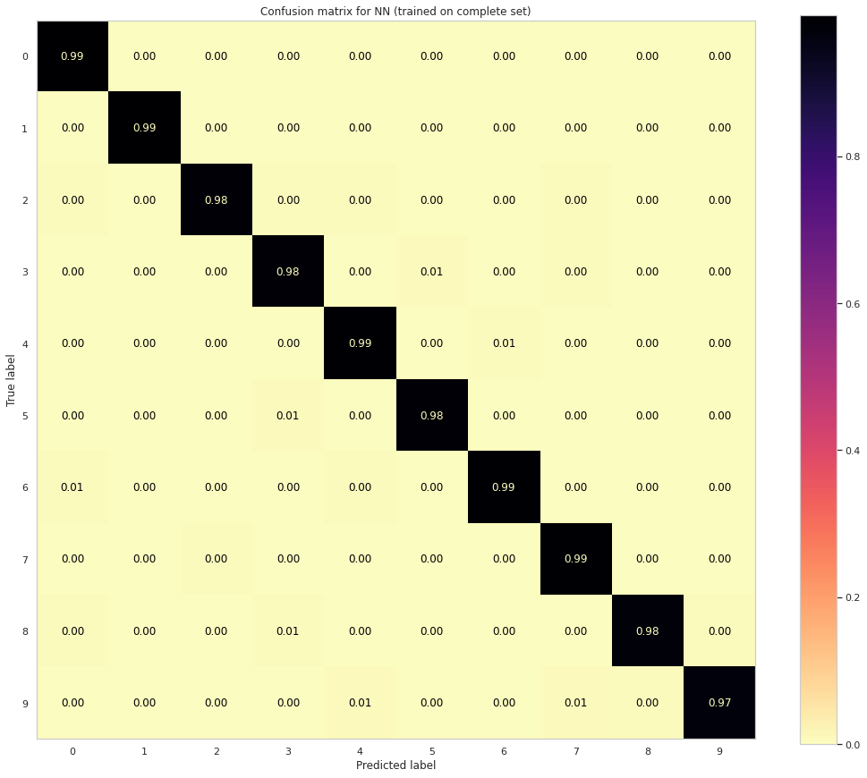

```python
# classifier wich takes a validation set
model = MLPClassifier(hidden_layer_sizes=(1024, 1024, 10),
                      activation='relu', solver='adam',
                      batch_size=64, learning_rate='adaptive',
                      early_stopping=True, validation_fraction=0.1,
                      verbose=True)

# training with the complete set
model.fit(x_train_complete, y_train_complete)

print("\nModel has {0:.2f}% accuracy on train set and {1:.2f}% accuracy on test set".format(\
        model.score(x_train_complete, y_train_complete)*100, model.score(x_test, y_test)*100))

# new confusion matrix
fig, ax = plt.subplots(1, 1, figsize = (18, 15))
disp = plot_confusion_matrix(model, x_test, y_test, display_labels=range(10),
                             cmap=plt.cm.magma_r, normalize='true',
                             ax=ax, values_format='.2f')
disp.ax_.set_title('Confusion matrix for NN (trained on complete set)')
plt.grid(False)
plt.show()
```

### 4 Support vector machines

The SVM is a very powerfullway to classify data, we can call it a *improved perceptron*. [Sklearn has a lot of content about SVM](https://scikit-learn.org/stable/modules/svm.html) and has a very powerfull library for it. If we have $n\_classes$ number of diferent classes in our data the classifier supports the **one-versus-one** method for classification, this is, it will produce ${n\_classes \choose 2}$ diferent SVMs, one for each pair of classes. But as our dataset is a little big, we are going with the **one-versus-rest** approach, resulting in only $n\_classes$ SVMs.

Particularly we are using the [linear support vector classification](https://scikit-learn.org/stable/modules/generated/sklearn.svm.LinearSVC.html#sklearn.svm.LinearSVC) class of sklearn. Here again we are going to print the accuracy of this model together with the confusion matrix. We will use the reduced train set for training

```
[LibLinear]Model has 93.98% accuracy on train set and 90.76% accuracy on test set
```

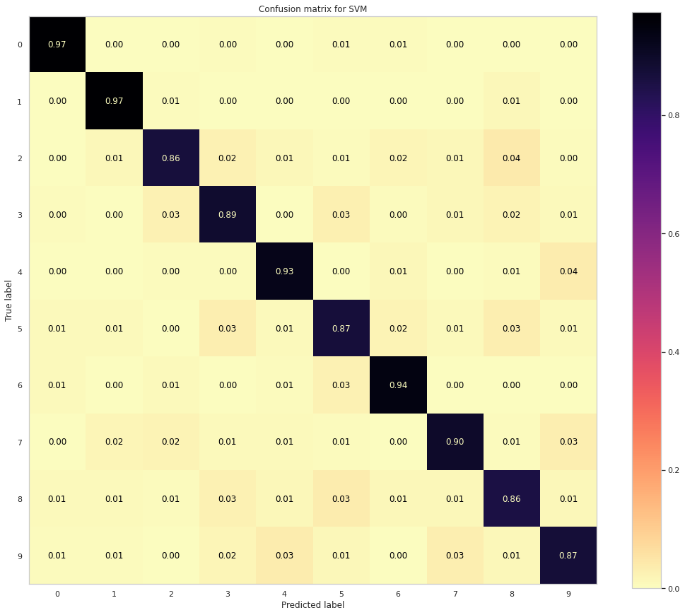

```python
from sklearn.svm import LinearSVC

model = LinearSVC(verbose=10)
model.fit(x_train, y_train)

print("Model has {0:.2f}% accuracy on train set and {1:.2f}% accuracy on test set".format(\
        model.score(x_train, y_train)*100, model.score(x_test, y_test)*100))

fig, ax = plt.subplots(1, 1, figsize = (18, 15))
disp = plot_confusion_matrix(model, x_test, y_test, display_labels=range(10),
                             cmap=plt.cm.magma_r, normalize='true',
                             ax=ax, values_format='.2f')
disp.ax_.set_title('Confusion matrix for SVM')
plt.grid(False)
plt.show()
```